# Pima Indian Diabetes Prediction

The aim of this project to analyze the medical factors of a patient such as Glucose Level, Blood Pressure, Skin Thickness, Insulin Level and many others to predict whether the patient has diabetes or not.

About the Dataset This dataset is originally from the National Institute of Diabetes and Digestive and Kidney Diseases. The objective of the dataset is to diagnostically predict whether or not a patient has diabetes, based on certain diagnostic measurements included in the dataset. Several constraints were placed on the selection of these instances from a larger database. In particular, all patients here are females at least 21 years old of Pima Indian heritage.

The datasets consists of several medical predictor variables and one target variable, Outcome. Predictor variables includes the number of pregnancies the patient has had, their BMI, insulin level, age, and so on.

### Data Dictionary

| Feature | Description |
| --- | --- |
| Pregnancies | Number of times pregnant |
| Glucose | Plasma glucose concentration a 2 hours in an oral glucose tolerance test |
| BloodPressure | Diastolic blood pressure (mm Hg) |
| SkinThickness | Triceps skin fold thickness (mm) |
| Insulin | 2-Hour serum insulin (mu U/ml) |
| BMI | Body mass index (weight in kg/(height in m)^2) |
| DiabetesPedigreeFunction | Diabetes pedigree function |
| Age | Age (years) |
| Outcome | Class variable (0 or 1) |

## Impact

The Pima Indian Diabetes Prediction project holds significant potential for impacting healthcare outcomes for Pima Indian females. Early detection and diagnosis of diabetes can play a crucial role in managing the condition effectively and preventing complications. By developing an accurate predictive model, healthcare providers can identify individuals at higher risk of diabetes and offer timely interventions and personalized treatment plans. This project's successful implementation may lead to improved health management strategies, reduced healthcare costs, and enhanced overall well-being for the Pima Indian female community. Additionally, the insights gained from this study may contribute to broader research on diabetes risk factors and aid in formulating targeted public health initiatives for diabetes prevention and awareness within the Pima Indian population. The ethical and responsible use of data in this project will be ensured to protect patient privacy and promote transparency in the application of predictive modeling in healthcare settings.

```python
import numpy as np
import pandas as pd
import matplotlib.pyplot as plt
import seaborn as sns
```

```python
df=pd.read_csv('diabetes.csv')
```

```python
df.head()
```

|  | Pregnancies | Glucose | BloodPressure | SkinThickness | Insulin | BMI | DiabetesPedigreeFunction | Age | Outcome |
| --- | --- | --- | --- | --- | --- | --- | --- | --- | --- |
| 0 | 6 | 148 | 72 | 35 | 0 | 33.6 | 0.627 | 50 | 1 |
| 1 | 1 | 85 | 66 | 29 | 0 | 26.6 | 0.351 | 31 | 0 |
| 2 | 8 | 183 | 64 | 0 | 0 | 23.3 | 0.672 | 32 | 1 |
| 3 | 1 | 89 | 66 | 23 | 94 | 28.1 | 0.167 | 21 | 0 |
| 4 | 0 | 137 | 40 | 35 | 168 | 43.1 | 2.288 | 33 | 1 |

```python
df.tail()
```

|  | Pregnancies | Glucose | BloodPressure | SkinThickness | Insulin | BMI | DiabetesPedigreeFunction | Age | Outcome |
| --- | --- | --- | --- | --- | --- | --- | --- | --- | --- |
| 763 | 10 | 101 | 76 | 48 | 180 | 32.9 | 0.171 | 63 | 0 |
| 764 | 2 | 122 | 70 | 27 | 0 | 36.8 | 0.340 | 27 | 0 |
| 765 | 5 | 121 | 72 | 23 | 112 | 26.2 | 0.245 | 30 | 0 |
| 766 | 1 | 126 | 60 | 0 | 0 | 30.1 | 0.349 | 47 | 1 |
| 767 | 1 | 93 | 70 | 31 | 0 | 30.4 | 0.315 | 23 | 0 |

```python
df.info()
```

```
<class 'pandas.core.frame.DataFrame'>
RangeIndex: 768 entries, 0 to 767
Data columns (total 9 columns):
 #   Column                    Non-Null Count  Dtype
---  ------                    --------------  -----
 0   Pregnancies               768 non-null    int64
 1   Glucose                   768 non-null    int64
 2   BloodPressure             768 non-null    int64
 3   SkinThickness             768 non-null    int64
 4   Insulin                   768 non-null    int64
 5   BMI                       768 non-null    float64
 6   DiabetesPedigreeFunction  768 non-null    float64
 7   Age                       768 non-null    int64
 8   Outcome                   768 non-null    int64
dtypes: float64(2), int64(7)
memory usage: 54.1 KB
```

```python
df.shape
```

```
(768, 9)
```

```python
df.describe()
```

|  | Pregnancies | Glucose | BloodPressure | SkinThickness | Insulin | BMI | DiabetesPedigreeFunction | Age | Outcome |
| --- | --- | --- | --- | --- | --- | --- | --- | --- | --- |
| count | 768.000000 | 768.000000 | 768.000000 | 768.000000 | 768.000000 | 768.000000 | 768.000000 | 768.000000 | 768.000000 |
| mean | 3.845052 | 120.894531 | 69.105469 | 20.536458 | 79.799479 | 31.992578 | 0.471876 | 33.240885 | 0.348958 |
| std | 3.369578 | 31.972618 | 19.355807 | 15.952218 | 115.244002 | 7.884160 | 0.331329 | 11.760232 | 0.476951 |
| min | 0.000000 | 0.000000 | 0.000000 | 0.000000 | 0.000000 | 0.000000 | 0.078000 | 21.000000 | 0.000000 |
| 25% | 1.000000 | 99.000000 | 62.000000 | 0.000000 | 0.000000 | 27.300000 | 0.243750 | 24.000000 | 0.000000 |
| 50% | 3.000000 | 117.000000 | 72.000000 | 23.000000 | 30.500000 | 32.000000 | 0.372500 | 29.000000 | 0.000000 |
| 75% | 6.000000 | 140.250000 | 80.000000 | 32.000000 | 127.250000 | 36.600000 | 0.626250 | 41.000000 | 1.000000 |
| max | 17.000000 | 199.000000 | 122.000000 | 99.000000 | 846.000000 | 67.100000 | 2.420000 | 81.000000 | 1.000000 |

```python
df.nunique()
```

```
Pregnancies                  17
Glucose                     136
BloodPressure                47
SkinThickness                51
Insulin                     186
BMI                         248
DiabetesPedigreeFunction    517
Age                          52
Outcome                       2
dtype: int64
```

Checking the unique values for each variable in the dataset

```python
#checking unique values
variables = ['Pregnancies','Glucose','BloodPressure','SkinThickness','Insulin','BMI','DiabetesPedigreeFunction','Age','Outcome']
for i in variables:
    print(df[i].unique())
```

[output not shown]

[output cut: 37 more lines]

```
 0.525 0.154 0.771 0.107 0.493 0.717 0.917 0.501 1.251 0.735 0.804 0.661
 0.549 0.825 0.423 1.034 0.16  0.341 0.68  0.591 0.3   0.121 0.502 0.401
 0.601 0.748 0.338 0.43  0.892 0.813 0.693 0.575 0.371 0.206 0.417 1.154
 0.925 0.175 1.699 0.682 0.194 0.4   0.1   1.258 0.482 0.138 0.593 0.878
 0.157 1.282 0.141 0.246 1.698 1.461 0.347 0.362 0.393 0.144 0.732 0.115
 0.465 0.649 0.871 0.149 0.695 0.303 0.61  0.73  0.447 0.455 0.133 0.155
 1.162 1.292 0.182 1.394 0.217 0.631 0.88  0.614 0.332 0.366 0.181 0.828
 0.335 0.856 0.886 0.439 0.253 0.598 0.904 0.483 0.565 0.118 0.177 0.176
 0.295 0.441 0.352 0.826 0.97  0.595 0.317 0.265 0.646 0.426 0.56  0.515
 0.453 0.785 0.734 1.174 0.488 0.358 1.096 0.408 1.182 0.222 1.057 0.766
 0.171]
[50 31 32 21 33 30 26 29 53 54 34 57 59 51 27 41 43 22 38 60 28 45 35 46
 56 37 48 40 25 24 58 42 44 39 36 23 61 69 62 55 65 47 52 66 49 63 67 72
 81 64 70 68]
[1 0]
```

In the dataset the variables except Pregnancies and Outcome cannot have value as 0, because it is not possible to have 0 Glucose Level or to have 0 Blood Pressure. So, this will be counted as incorrect information

Checking the count of value 0 in the variables

```python
variables = ['Glucose','BloodPressure','SkinThickness','Insulin','BMI','DiabetesPedigreeFunction','Age',]
for i in variables:
    c = 0
    for x in (df[i]):
        if x == 0:
            c = c + 1
    print(i,c)
```

```
Glucose 5
BloodPressure 35
SkinThickness 227
Insulin 374
BMI 11
DiabetesPedigreeFunction 0
Age 0
```

```python
# Fill missing values in each column with the mean of that column
variables = ['Glucose','BloodPressure','SkinThickness','Insulin','BMI']
for column in variables:
    mean_value = df[column].mean()
    df[column].fillna(mean_value, inplace=True)
```

```python
missing_value_counts = {}

# Loop through columns and count missing values
for column in variables:
    missing_count = df[column].isnull().sum()
    missing_value_counts[column] = missing_count
```

```python
print(missing_value_counts)
```

```
{'Glucose': 0, 'BloodPressure': 0, 'SkinThickness': 0, 'Insulin': 0, 'BMI': 0}
```

## Exploratory Data Analysis

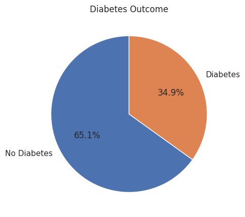

```python
plt.figure(figsize=(5,5))
plt.pie(df['Outcome'].value_counts(), labels=['No Diabetes', 'Diabetes'], autopct='%1.1f%%', shadow=False, startangle=90)
plt.title('Diabetes Outcome')
plt.show()
```

```python
numeric_columns = ['Pregnancies', 'Glucose', 'BloodPressure', 'SkinThickness', 'Insulin', 'BMI', 'DiabetesPedigreeFunction', 'Age']
summary_stats = df[numeric_columns].describe()
```

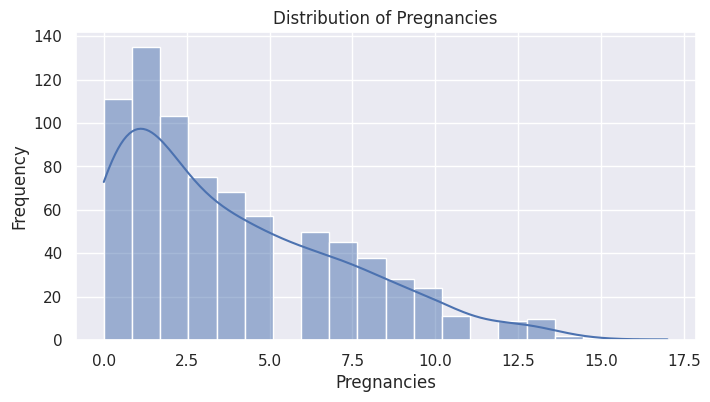

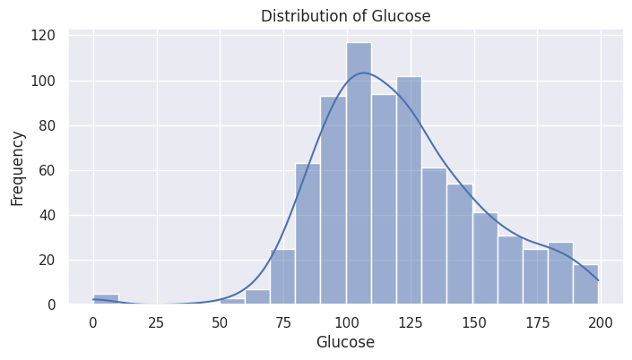

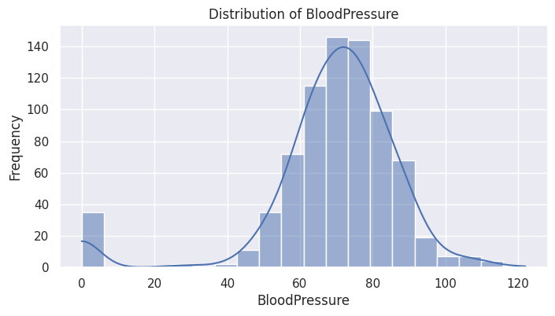

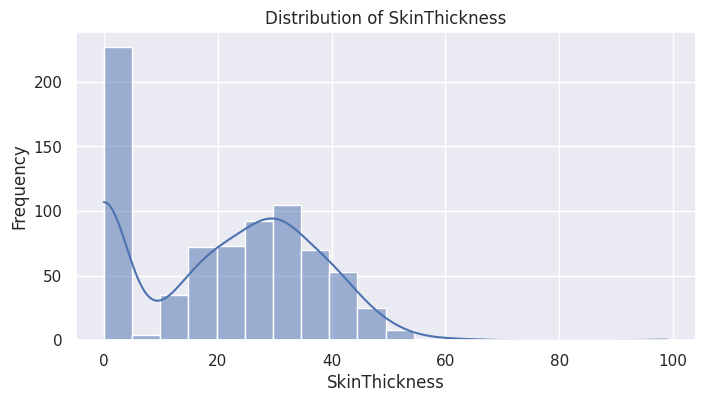

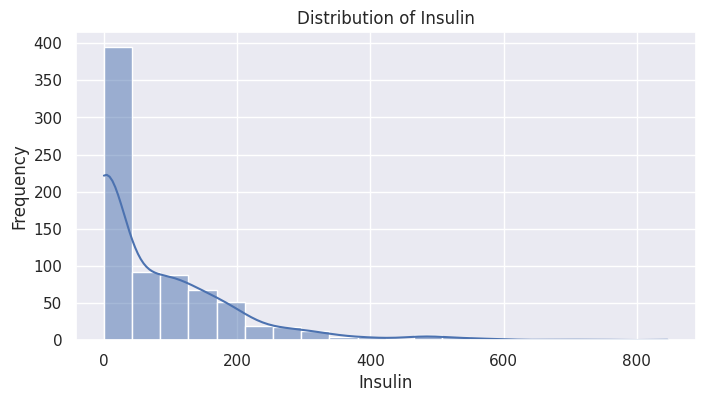

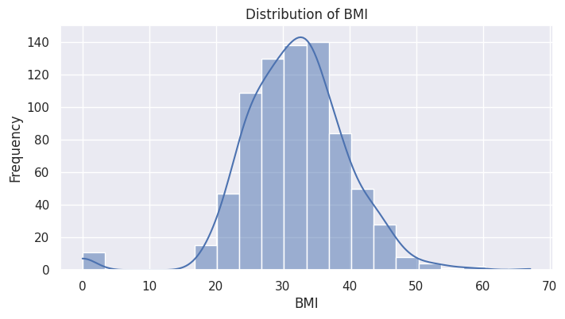

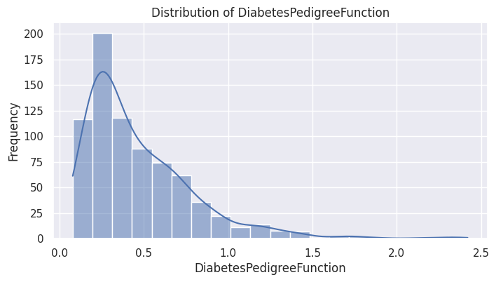

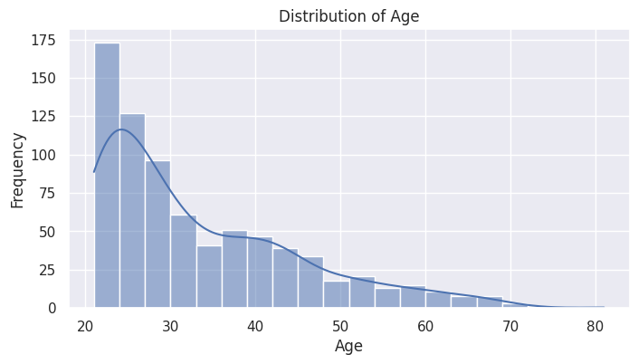

```python
# Distribution plots for numeric columns

for column in numeric_columns:
    plt.figure(figsize=(8, 4))
    sns.histplot(df[column], kde=True, bins=20)
    plt.title(f'Distribution of {column}')
    plt.xlabel(column)
    plt.ylabel('Frequency')
    plt.show()
```

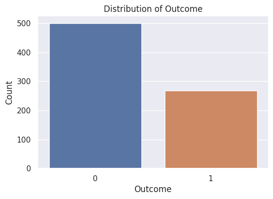

```python
# Distribution of the 'Outcome' column (assuming it's binary)
plt.figure(figsize=(6, 4))
sns.countplot(data=df, x='Outcome')
plt.title('Distribution of Outcome')
plt.xlabel('Outcome')
plt.ylabel('Count')
plt.show()
```

Age Distribution and Diabetes

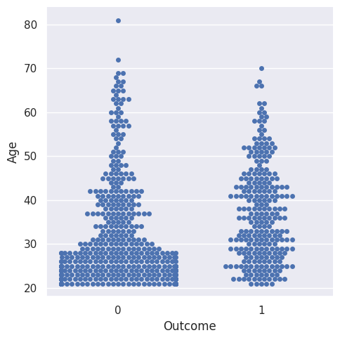

```python
sns.catplot(x="Outcome", y="Age", kind="swarm", data=df)
```

From the graph, it is quite clear that majority of the patients are adult within the age group of 20-30 years. Patients in the age range 40-55 years are more prone to diabetes, as compared to other age groups. Since the number adults in the age group 20-30 years is more, the number of patients with diabetes is also more as compared of other age groups.

Pregnancies and Diabetes

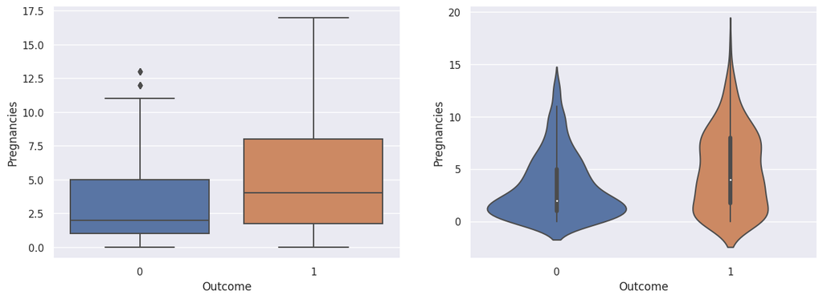

```python
fig,ax = plt.subplots(1,2,figsize=(15,5))
sns.boxplot(x='Outcome',y='Pregnancies',data=df,ax=ax[0])
sns.violinplot(x='Outcome',y='Pregnancies',data=df,ax=ax[1])
```

Both boxplot and violinplot shows strange relation between the number of preganacies and diabetes. According to the graphs the increased number of pregnancies highlights increased risk of diabetes.

Glucose and Diabetes

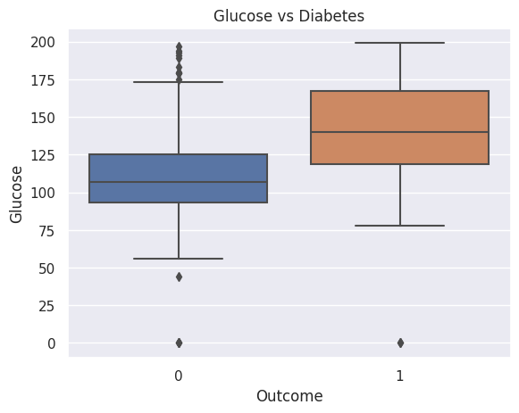

```python
sns.boxplot(x='Outcome', y='Glucose', data=df).set_title('Glucose vs Diabetes')
```

Glucose level plays a major role in determine whether the patient is diabetic or not. The patients with median gluocse level less than 120 are more likely to be non-diabetic. The patients with median gluocse level greather than 140 are more likely to be diabetic. Therefore, high gluocose levels is a good indicator of diabetes.

Blood Pressuse and Diabetes

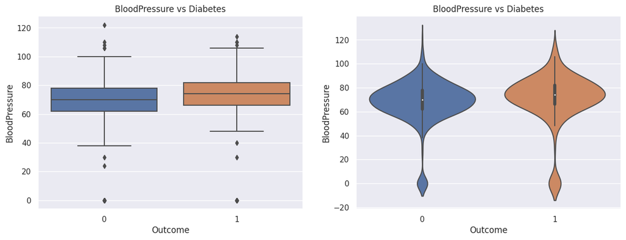

```python
fig,ax = plt.subplots(1,2,figsize=(15,5))
sns.boxplot(x='Outcome', y='BloodPressure', data=df, ax=ax[0]).set_title('BloodPressure vs Diabetes')
sns.violinplot(x='Outcome', y='BloodPressure', data=df, ax=ax[1]).set_title('BloodPressure vs Diabetes')
```

Both the boxplot and voilinplot provides clear understanding of the realtion between the blood pressure and diabetes. The boxplot shows that the median of the blood pressure for the diabetic patients is slightly higher than the non-diabetic patients. The voilinplot shows that the distribution of the blood pressure for the diabetic patients is slightly higher than the non-diabetic patients. But there has been not enough evidence to conclude that the blood pressure is a good predictor of diabetes.

Skin Thickness and Diabetes

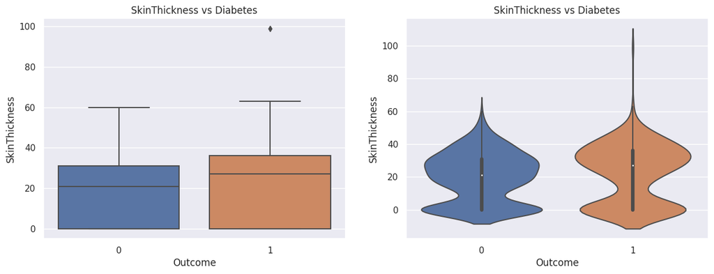

```python
fig,ax = plt.subplots(1,2,figsize=(15,5))
sns.boxplot(x='Outcome', y='SkinThickness', data=df,ax=ax[0]).set_title('SkinThickness vs Diabetes')
sns.violinplot(x='Outcome', y='SkinThickness', data=df,ax=ax[1]).set_title('SkinThickness vs Diabetes')
```

Here both the boxplot and violinplot reveals the effect of diabetes on skin thickness. As obserevd in the boxplot, the median of skin thickness is higher for the diabetic patients than the non-diabetic patients, where non diabetic patients have median skin thickness near 20 in comparison to skin thickness nearly 30 in diabetic patients. The voilinpplot shows the distribution of patients' skin thickness amoung the patients, where the non diabetic ones have greater distribution near 20 and diabetic much less distribution near 20 and increased distribution near 30. Therefore, skin thickness can be a indicator of diabetes.

Insulin and Diabetes

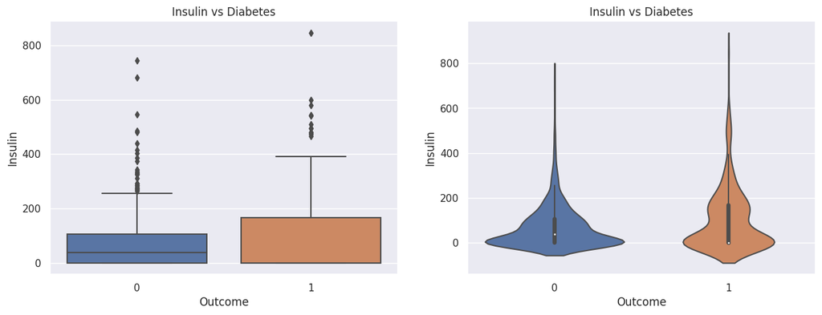

```python
fig,ax = plt.subplots(1,2,figsize=(15,5))
sns.boxplot(x='Outcome',y='Insulin',data=df,ax=ax[0]).set_title('Insulin vs Diabetes')
sns.violinplot(x='Outcome',y='Insulin',data=df,ax=ax[1]).set_title('Insulin vs Diabetes')
```

BMI and Diabetes

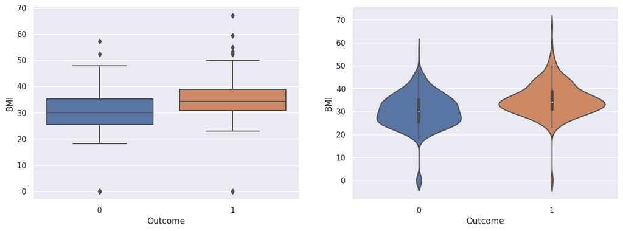

```python
fig,ax = plt.subplots(1,2,figsize=(15,5))
sns.boxplot(x='Outcome',y='BMI',data=df,ax=ax[0])
sns.violinplot(x='Outcome',y='BMI',data=df,ax=ax[1])
```

Diabetes Pedigree Function and Diabetes Outcome

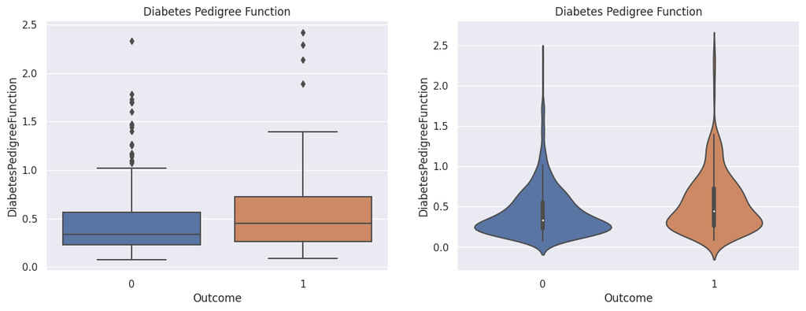

```python
fig,ax = plt.subplots(1,2,figsize=(15,5))
sns.boxplot(x='Outcome',y='DiabetesPedigreeFunction',data=df,ax=ax[0]).set_title('Diabetes Pedigree Function')
sns.violinplot(x='Outcome',y='DiabetesPedigreeFunction',data=df,ax=ax[1]).set_title('Diabetes Pedigree Function')
```

Diabetes Pedigree Function (DPF) calculates diabetes likelihood depending on the subject's age and his/her diabetic family history. From the boxplot, the patients with lower DPF, are much less likely to have diabetes. The patients with higher DPF, are much more likely to have diabetes. In the violinplot, majority of the non diabetic patients have a DPF of 0.25-0.35, whereas the diabetic patients have a increased DPF, which is shown by the their distribution in the violinplot where there is a increased spread in the DPF from 0.5 -1.5. Therefore the DPF is a good indicator of diabetes.

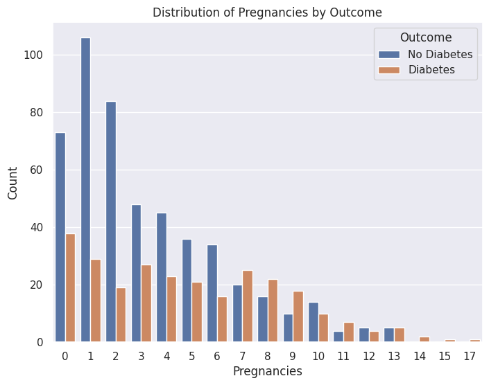

```python
# 1. Categorical vs. Categorical
plt.figure(figsize=(8, 6))
sns.countplot(data=df, x='Pregnancies', hue='Outcome')
plt.title('Distribution of Pregnancies by Outcome')
plt.xlabel('Pregnancies')
plt.ylabel('Count')
plt.legend(title='Outcome', labels=['No Diabetes', 'Diabetes'])
plt.show()
```

```python
from scipy.stats import chi2_contingency, ttest_ind
# Chi-squared test for independence
contingency_table = pd.crosstab(df['Pregnancies'], df['Outcome'])
chi2, p, _, _ = chi2_contingency(contingency_table)
print(f"Chi-squared p-value: {p}")
```

```
Chi-squared p-value: 8.648349123362548e-08
```

The p-value from a chi-squared test for independence represents the probability of observing the observed association (or more extreme) between two categorical variables, such as 'Pregnancies' and 'Outcome,' under the assumption that there is no actual association (independence) between them.

where the p-value is approximately 8.65e-08 (very close to zero), this extremely small p-value indicates the following:

Statistical Significance: The chi-squared test has found strong evidence to reject the null hypothesis. The null hypothesis in this context would typically be that there is no association or independence between 'Pregnancies' and 'Outcome.'

Association or Dependence: The small p-value suggests that there is a significant association or dependence between the number of pregnancies ('Pregnancies') and the outcome of the diabetes test ('Outcome') in your dataset.

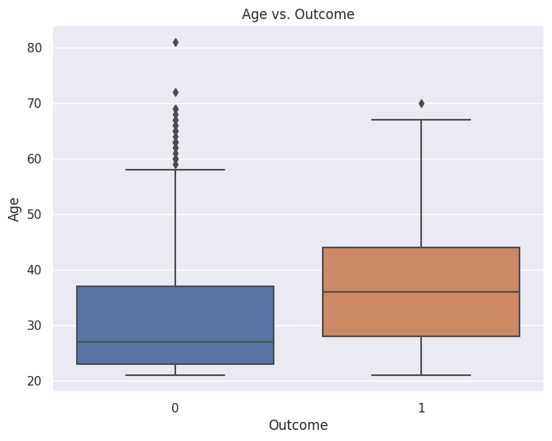

```python
# 2. Categorical vs. Numerical
plt.figure(figsize=(8, 6))
sns.boxplot(data=df, x='Outcome', y='Age')
plt.title('Age vs. Outcome')
plt.xlabel('Outcome')
plt.ylabel('Age')
plt.show()
```

```python
# t-test for difference in means
no_diabetes_age = df[df['Outcome'] == 0]['Age']
diabetes_age = df[df['Outcome'] == 1]['Age']
t_stat, p_value = ttest_ind(no_diabetes_age, diabetes_age)
print(f"t-test p-value for Age and Outcome: {p_value}")
```

```
t-test p-value for Age and Outcome: 2.2099754606654358e-11
```

The p-value you obtained from the t-test for 'Age' and 'Outcome' is approximately 2.21e-11, which is an extremely small number. In simple terms, here's what you can understand from this result:

Statistical Significance: The small p-value (much less than 0.05 or any common significance level) indicates strong evidence against the idea that there is no difference in the average ages between the two groups (diabetes and no diabetes).

Difference in Means: A small p-value suggests that there is a statistically significant difference in the average ages of individuals with diabetes and those without diabetes.

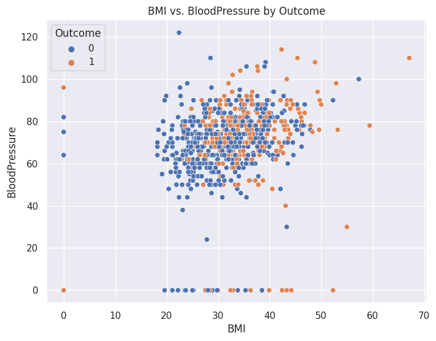

```python
# 3. Numerical vs. Numerical
plt.figure(figsize=(8, 6))
sns.scatterplot(data=df, x='BMI', y='BloodPressure', hue='Outcome')
plt.title('BMI vs. BloodPressure by Outcome')
plt.xlabel('BMI')
plt.ylabel('BloodPressure')
plt.show()
```

```python
#Correlation between BMI and BloodPressure
correlation = df[['BMI', 'BloodPressure']].corr(method='pearson')
print("Correlation matrix between BMI and BloodPressure:")
print(correlation)
```

```
Correlation matrix between BMI and BloodPressure:
                    BMI  BloodPressure
BMI            1.000000       0.281805
BloodPressure  0.281805       1.000000
```

Correlation Coefficient Values:

The correlation coefficient between 'BMI' and 'BloodPressure' is approximately 0.282. This value is between -1 and 1. A positive correlation coefficient (0.282) indicates a positive linear relationship, meaning that as 'BMI' increases, 'BloodPressure' tends to increase as well. However, the correlation is relatively weak, as the coefficient is closer to 0 than to 1. Strength of Relationship:

The correlation coefficient of 0.282 suggests a relatively weak positive relationship between 'BMI' and 'BloodPressure.' This means that while there is a tendency for these variables to increase together, the relationship is not very strong. Interpretation:

In practical terms, this correlation suggests that there is some degree of association between higher BMI values and higher blood pressure values. This is consistent with the common understanding that excess body weight (higher BMI) can be a risk factor for elevated blood pressure. Magnitude of Correlation:

The magnitude of the correlation coefficient (0.282) indicates that while there is a relationship, it may not be the only factor influencing blood pressure. Other factors could also play a significant role.

In summary, the correlation matrix suggests a weak positive linear relationship between 'BMI' and 'BloodPressure' in your dataset. It's important to note that correlation does not imply causation. While these variables are correlated, it doesn't necessarily mean that one directly causes the other; other factors and mechanisms may be involved.

```python
correlation_matrix=df.corr()
```

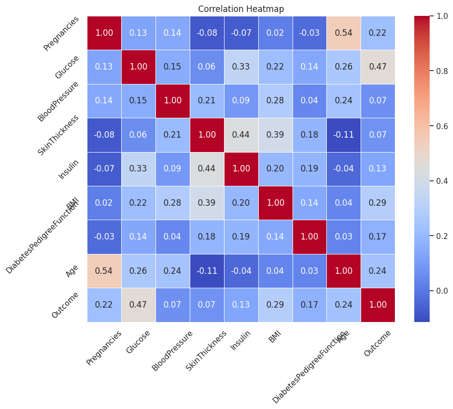

```python
plt.figure(figsize=(10, 8))  # Adjust the figure size as needed

# Create a heatmap using Seaborn
sns.set(font_scale=1.0)  # Adjust the font size as needed
sns.heatmap(correlation_matrix, annot=True, fmt=".2f", cmap="coolwarm", linewidths=0.5)

# Customize the plot
plt.title("Correlation Heatmap")
plt.xticks(rotation=45)
plt.yticks(rotation=45)

# Display the heatmap
plt.show()
```

```python
from sklearn.model_selection import train_test_split
X_train, X_test, y_train, y_test = train_test_split(df.drop('Outcome',axis=1),df['Outcome'],test_size=0.2,random_state=42)
```